# Are World Happiness and Suicide Linked?

#### *Data Used In This Project*

*World Happiness Index*  
https://www.kaggle.com/mathurinache/world-happiness-report  
(2015-2020) 2015.csv - 2020.csv

*Suicide Rates*  
https://www.kaggle.com/szamil/who-suicide-statistics  
(1979-2017) who_suicide_stastistics.csv

#### *Hypotheses*

- Countries with a higher happiness index will have lower sucide rates and countries with s lower hapiness index will have higher suicide rates

#### *Import Packages*

```python
import numpy as np
import pandas as pd
import matplotlib.pyplot as plt
from scipy.stats import iqr
import statsmodels.formula.api as smf
```

## Data Wrangling World Happiness Datasets

*Load and combine World Happiness datasets from 2015-2018*

```python
whi_2015 = pd.read_csv("RawData/World_Happiness_15-2020/2015.csv")
whi_2016 = pd.read_csv("RawData/World_Happiness_15-2020/2016.csv")
whi_2017 = pd.read_csv("RawData/World_Happiness_15-2020/2017.csv")
whi_2018 = pd.read_csv("RawData/World_Happiness_15-2020/2018.csv")
```

```python
print("2015:\n", whi_2015.columns)
print("2016:\n", whi_2016.columns)
print("2017:\n", whi_2017.columns)
print("2018:\n", whi_2018.columns)

## Column names are different between years, some columns not present in all years.
```

```python
## Subset columns to keep in analysis
sub2015 = whi_2015.loc[:,('Country', 'Happiness Score', 'Economy (GDP per Capita)', 'Family', 'Health (Life Expectancy)', 'Freedom',\
                          'Trust (Government Corruption)', 'Generosity')]
sub2016 = whi_2016.loc[:,('Country', 'Happiness Score', 'Economy (GDP per Capita)', 'Family', 'Health (Life Expectancy)', 'Freedom',\
                          'Trust (Government Corruption)', 'Generosity')]
sub2017 = whi_2017.loc[:,('Country', 'Happiness.Score', 'Economy..GDP.per.Capita.', 'Family', 'Health..Life.Expectancy.', 'Freedom',\
                          'Trust..Government.Corruption.', 'Generosity')]
sub2018 = whi_2018.loc[:,('Country or region', 'Score', 'GDP per capita', 'Social support', 'Healthy life expectancy', 'Freedom to make life choices',\
                          'Perceptions of corruption', 'Generosity')]

## Rename columns so they all match
colnames = ['Country', 'Happiness', 'GDP', 'Support', 'Life_Expt', 'Freedom', 'Corruption', 'Generosity']

sub2015.columns = colnames
sub2016.columns = colnames
sub2017.columns = colnames
sub2018.columns = colnames

## Add Year column
sub2015["Year"] = 2015
sub2016["Year"] = 2016
sub2017["Year"] = 2017
sub2018["Year"] = 2018

## Check order of colnames and join together
print(sub2015.columns)
print(sub2016.columns)
print(sub2017.columns)
print(sub2018.columns)

happiness = sub2015.append([sub2016, sub2017, sub2018], ignore_index = True)
happiness.isnull().any() ## Check NAs: Corruption has NAs
print(happiness.shape) ## (626, 9)
print(happiness.columns)

## Save result as new csv, Corruption has NAs
happiness.to_csv("World_Happiness_2015_2018.csv", sep= ",")
```

## Data Wrangling Suicide Dataset

*Load suicide dataset, filter for years 2015 - 2016, remove NAs*

```python
suicide = pd.read_csv("RawData/who_suicide_statistics.csv")
suicide["year"].max()

## filter for years 2015-2016
suicide_sub = suicide[suicide["year"] >= 2015]

## remove NAs: suicides_no and population both have NAs
suicide_sub.isnull().any()
suicide_na = suicide_sub[suicide_sub["suicides_no"].notna() & suicide_sub["population"].notna()]
suicide_na.isnull().any()

## filter happiness for years 2015 & 2016
happiness_sub = happiness[(happiness["Year"] == 2015) | (happiness["Year"] == 2016)]
happiness_sub["Year"].unique()
happiness_sub.isna().any() ## No NAs
```

*Rename countries that are shared but not named the same between dataframes*

```python
## Find countries with the same names in both suicide and happiness index datasets
sharedCountries = np.intersect1d(suicide_na["country"].unique(), happiness_sub["Country"].unique())

## Check other countries for name variences
print("Suicide DF\n")
for each in list(suicide_na["country"].unique()):
    if each not in sharedCountries:
        print(each)

print("\nHappiness DF\n")
for each in list(happiness_sub["Country"].unique()):
    if each not in sharedCountries:
        print(each)

changenames = {'Republic of Korea': 'South Korea', 'Hong Kong SAR': 'Hong Kong', 'United States of America':'United States', 'Republic of Moldova':'Moldova',\
               'Iran (Islamic Rep of)':'Iran', 'Russian Federation': 'Russia'}

suicide_na.loc[:,"country"] = suicide_na.loc[:,"country"].replace(changenames)
suicide_na["country"].unique()
```

*Combine suicide and world happiness datasets by year and country*

```python
happiness_suicide = pd.merge(suicide_na, happiness_sub, how = "inner", left_on = ["country","year"], right_on = ["Country","Year"])
happiness_suicide = happiness_suicide[['country', 'year', 'sex', 'age', 'suicides_no', 'population', 'Happiness', 'GDP', 'Support',\
                                       'Life_Expt', 'Freedom', 'Corruption', 'Generosity']]

## Save dataframe to use later
happiness_suicide.to_csv("happiness_suicide.csv", sep= ",")
```

## **Plotting Variables, Exploring the Data**

#### A Look at the Suicide Data

- What are the outliers in the data?
- What year had the highest average rate of worldwide suicides?
- What country has the highest rate of suicides?
- What age range has the highest rate of suicides?
- What country has the highest rate of young suicides?

```python
happiness_suicide = pd.read_csv("happiness_suicide.csv")
happiness_suicide = happiness_suicide.loc[:,"country":]
happiness_suicide.head ## 900 rows by 13 columns

## Normalize suicides to population to compare across countries
happiness_suicide['suicides_per100k'] = (happiness_suicide['suicides_no']/happiness_suicide['population'])*100000
print(happiness_suicide["suicides_per100k"].describe())
```

```
count    900.000000
mean      11.607624
std       15.455821
min        0.000000
25%        1.670565
50%        6.305144
75%       14.825127
max      140.741557
Name: suicides_per100k, dtype: float64
```

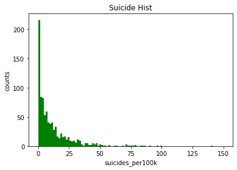

```python
## Histogram of Suicides
range_suicides= (0, 150)
bins = 100
plt.hist(happiness_suicide["suicides_per100k"], bins, range_suicides, color = "green")
plt.ylabel('counts')
plt.xlabel('suicides_per100k')
plt.title('Suicide Hist')
plt.rcParams.update({'font.size': 15, "figure.figsize": (10,5)})
plt.show()
```

Heavy right skew distribution  
Most of the data falls between 0 and 50, with a long tail to 100  
There are obvious outliers between 100 and 150, explore the outliers more

#### What are the outliers?

- South Korea highest at 140.74 suicides per 100,000 people.
- Ages are higher with most in 75+ category, second largest group is 55-74 years.
- A lot of slavic countries in list of high outliers
- No low outliers

```python
suicide_iqr = iqr(happiness_suicide['suicides_per100k'])
print('IQR: ', suicide_iqr)

lower_thres = np.quantile(happiness_suicide['suicides_per100k'], 0.25) - 1.5 * suicide_iqr
upper_thres = np.quantile(happiness_suicide['suicides_per100k'], 0.75) + 1.5 * suicide_iqr

## filter for upper and lower outliers
highest_outliers = happiness_suicide[happiness_suicide['suicides_per100k'] > upper_thres]
lowest_outliers = happiness_suicide[happiness_suicide['suicides_per100k'] < lower_thres] ## Empty df; no low outliers

print(highest_outliers['country'].unique())
print(highest_outliers['age'].value_counts())
```

```
IQR:  13.154561478279565
['Austria' 'Belgium' 'Chile' 'Croatia' 'Czech Republic' 'Estonia'
 'Germany' 'Hong Kong' 'Hungary' 'Japan' 'Kazakhstan' 'Latvia' 'Lithuania'
 'Mongolia' 'Poland' 'South Korea' 'Moldova' 'Russia' 'Serbia' 'Slovenia'
 'Switzerland' 'Ukraine' 'United States' 'Uruguay']
75+ years      27
55-74 years    17
35-54 years     9
25-34 years     6
15-24 years     1
Name: age, dtype: int64
```

#### What year has a higher rate of suicides?

- Median better measure as data is skewed. Median ~6 suicides per year per 100,000 people.
- 2015 and 2016 seem similar in suicide rate per year for both mean and median, although 2015 has more datapoints

```python
## Yearly Worldwide Suicides
print("Number Datapoints Each Year:\n", happiness_suicide.groupby("year")["country"].count(), "\n")
# 2015: 708
# 2016: 192

print("Mean & Median Suicides Each Year:\n", happiness_suicide.groupby("year")["suicides_per100k"].agg([np.mean, np.median, np.var, np.std]))
```

```
Number Datapoints Each Year:
 year
2015    708
2016    192
Name: country, dtype: int64

Mean & Median Suicides Each Year:
            mean    median         var        std
year
2015  11.442142  6.304457  230.305651  15.175825
2016  12.217839  6.316670  271.404792  16.474368
```

#### What country has the highest suicide rate?

- Summarized by median: South Korea, Slovenia, Lithuania, Japan, Belgium, Latvia, Croatia, Hong Kong, Hungary, and Kazakhstan are top 10. US is #21.
- Countries on low end either have lower rates of suicide or don't report suicides/collect data

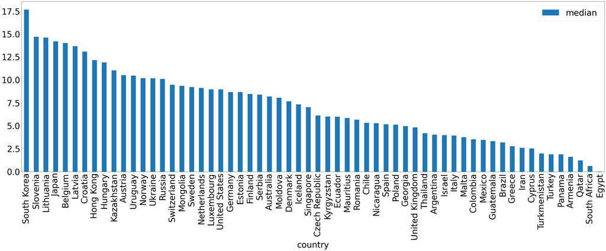

```python
## Median suicides by country
happiness_suicide.groupby("country")["suicides_per100k"].agg([np.median]).sort_values("median", ascending = False).plot(kind="bar")
plt.rcParams.update({'font.size': 30, "figure.figsize": (50,15)})
plt.show()
```

#### What age group has the highest rate of suicides?

- 75+, suicides seem to increase with age when summarized by mean or median.

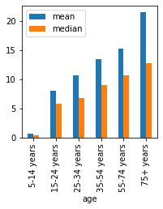

```python
## Suicides by age group

age_suicide = happiness_suicide.groupby("age")["suicides_per100k"].agg([np.mean, np.median])
age_suicide = age_suicide.reindex(index = ["5-14 years","15-24 years","25-34 years","35-54 years","55-74 years","75+ years"])
age_suicide.plot(kind="bar")
plt.rcParams.update({'font.size': 10, "figure.figsize": (3,3)})
plt.show()
```

#### What country has the highest rate of young suicides?

- Lithuania, Iceland, Mauritius, Mongolia, Moldova are the top 5 with higest rates. US is the 19th highest

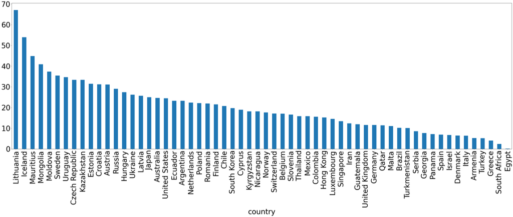

```python
## Young Suicides Bar Plot
young_suicides = happiness_suicide[happiness_suicide["age"] == ("15-24 years" or "5-14 years")]
grouped_young = young_suicides.groupby("country")["suicides_per100k"].sum().sort_values(ascending = False)
grouped_young.plot(kind="bar")
plt.rcParams.update({'font.size': 40, "figure.figsize": (50,15)})
plt.show()
```

#### A Look at the Happiness Data

- What are the outliers in the data?
- Are there differences between years?
- What country has the highest happiness?

```
count    900.000000
mean       6.113840
std        0.925975
min        4.194000
25%        5.477000
50%        5.984000
75%        6.937000
max        7.587000
Name: Happiness, dtype: float64
```

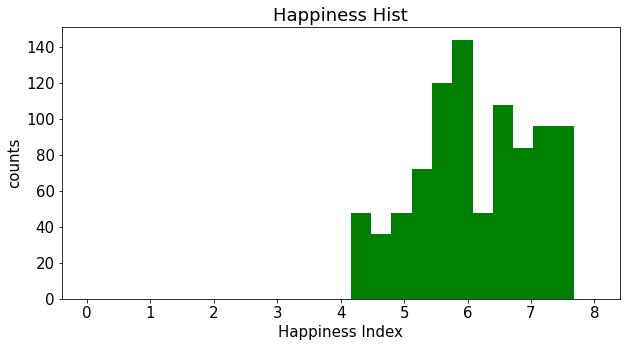

```python
## Histogram of Suicides
print(happiness_suicide['Happiness'].describe())

range_suicides= (0, 8)
bins = 25
plt.hist(happiness_suicide["Happiness"], bins, range_suicides, color = "green")
plt.ylabel('counts')
plt.xlabel('Happiness Index')
plt.title('Happiness Hist')
plt.rcParams.update({'font.size': 15, "figure.figsize": (10,5)})
plt.show()
```

```python
## Pretty normal distribution between 4 and 8
suicide_iqr = iqr(happiness_suicide['Happiness'])
print('IQR: ', suicide_iqr)

lower_thres = np.quantile(happiness_suicide['Happiness'], 0.25) - 1.5 * suicide_iqr
upper_thres = np.quantile(happiness_suicide['Happiness'], 0.75) + 1.5 * suicide_iqr

## filter for upper and lower outliers
highest_outliers = happiness_suicide[happiness_suicide['Happiness'] > upper_thres] # Empty df; no high outliers
lowest_outliers = happiness_suicide[happiness_suicide['Happiness'] < lower_thres] # Empty df; no high outliers

## Yearly Worldwide Suicides
print("Number Datapoints Each Year:\n", happiness_suicide.groupby("year")["country"].count(), "\n")
# 2015: 708
# 2016: 192

print("Mean & Median Suicides Each Year:\n", happiness_suicide.groupby("year")["Happiness"].agg([np.mean, np.median, np.var, np.std]))
```

```
IQR:  1.46
Number Datapoints Each Year:
 year
2015    708
2016    192
Name: country, dtype: int64

Mean & Median Suicides Each Year:
           mean  median       var       std
year
2015  6.127305   5.987  0.867165  0.931217
2016  6.064188   5.855  0.822733  0.907046
```

#### What country has the highest happiness index?

- Summarized by mean: Switzerland, Iceland, Denmark, Norway, Finland, Netherlands, Sweden, Australia, Israel, and Mexico are top 10. US is #12.

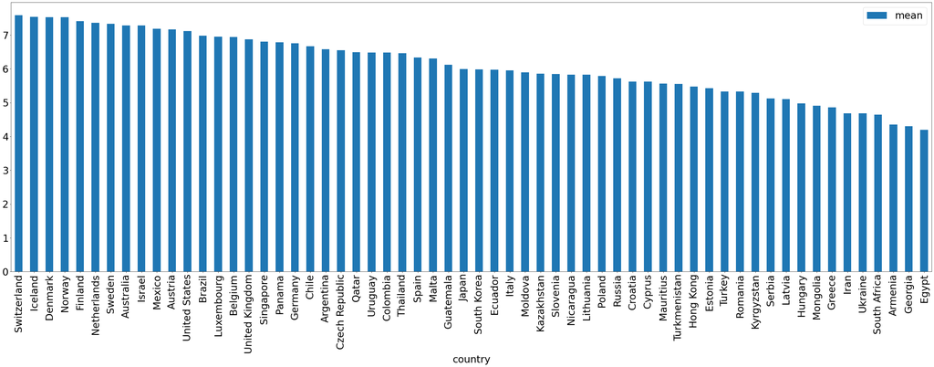

```python
## Mean happiness index for 2015 and 2016 by country
happiness_suicide.groupby("country")["Happiness"].agg([np.mean]).sort_values("mean", ascending = False).plot(kind="bar")
plt.rcParams.update({'font.size': 30, "figure.figsize": (50,15)})
plt.show()
```

## **Exploring Correlations Between Happiness and Suicide**

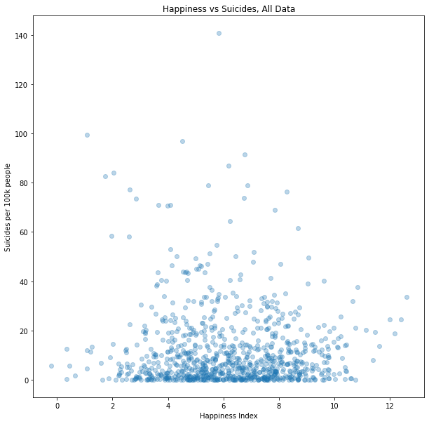

```python
## Scatter plot for happiness and suicides grouped by year
##First plot, Happiness needs jittering
happy_jittered = happiness_suicide['Happiness'] + np.random.normal(0, 2, size=len(happiness_suicide))
suicides = happiness_suicide['suicides_per100k']
plt.plot(happy_jittered, suicides, 'o', alpha=0.3)
plt.ylabel('Suicides per 100k people')
plt.xlabel('Happiness Index')
plt.title('Happiness vs Suicides, All Data')
plt.rcParams.update({'font.size': 10, "figure.figsize": (10,10)})
plt.show()
```

Parabolic relationship, higher rate of suicides for countries whose happiness index is ~6.

## Muliple Regression

Can suicides per 100,000 people be predicted by happiness index?

**Note:** I used all available data to explore, therefore should not use same data split into test/training datasets. Therefore I will not test my model.

```python
## Try happiness^2 first as parabolic curve that could fit data would be y=-x^2
happiness_suicide['Happiness2'] = happiness_suicide['Happiness']**2
model = smf.ols('suicides_per100k ~ Happiness + Happiness2', data=happiness_suicide)
results = model.fit()
results.params
```

```
Intercept    -55.295997
Happiness     22.455385
Happiness2    -1.840828
dtype: float64
```

[figure not shown]

```python
## Generate predictions to plot
df = pd.DataFrame()
df['Happiness'] = np.linspace(0,12)
df['Happiness2'] = df['Happiness']**2
predictions = results.predict(df)

## Plot model
happy_jittered = happiness_suicide['Happiness'] + np.random.normal(0, 2, size=len(happiness_suicide))
suicides = happiness_suicide['suicides_per100k']
plt.plot(df['Happiness'], predictions, label='Model')
plt.plot(happy_jittered, suicides, 'o', alpha=0.3)
plt.ylabel('Suicides per 100k people')
plt.ylim([0, 150])
plt.xlabel('Happiness Index')
plt.title('Happiness vs Suicides, Line of Best Fit: Happiness Only')
plt.rcParams.update({'font.size': 10, "figure.figsize": (10,10)})
plt.show()
```

Something else likely contributes to suicide prediction. Line of best fit seems low. Suicide rate definitly increases with age, so add age to multiple regression.

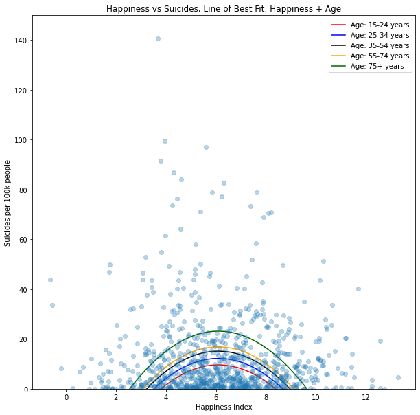

```python
model = smf.ols('suicides_per100k ~ C(age) + Happiness + Happiness2', data=happiness_suicide)
results = model.fit()
results.params

## Generate predictions to plot
df = pd.DataFrame()
df['Happiness'] = np.linspace(0,12)
df['Happiness2'] = df['Happiness']**2
df['age'] = '15-24 years' ## Parabola moves up with age input here, 75+ is the highest
predictions_15 = results.predict(df)
df['age'] = '25-34 years'
predictions_25 = results.predict(df)
df['age'] = '35-54 years'
predictions_35 = results.predict(df)
df['age'] = '55-74 years'
predictions_55 = results.predict(df)
df['age'] = '75+ years'
predictions_75 = results.predict(df)

## Plot model
happy_jittered = happiness_suicide['Happiness'] + np.random.normal(0, 2, size=len(happiness_suicide))
suicides = happiness_suicide['suicides_per100k']
plt.plot(df['Happiness'], predictions_15, label='Age: 15-24 years', color ='red')
plt.plot(df['Happiness'], predictions_25, label='Age: 25-34 years', color ='blue')
plt.plot(df['Happiness'], predictions_35, label='Age: 35-54 years', color ='black')
plt.plot(df['Happiness'], predictions_55, label='Age: 55-74 years', color ='orange')
plt.plot(df['Happiness'], predictions_75, label='Age: 75+ years', color ='darkgreen')
plt.plot(happy_jittered, suicides, 'o', alpha=0.3)
plt.ylabel('Suicides per 100k people')
plt.ylim([0, 150])
plt.xlabel('Happiness Index')
plt.title('Happiness vs Suicides, Line of Best Fit: Happiness + Age')
plt.legend(loc="upper right")
plt.rcParams.update({'font.size': 10, "figure.figsize": (10,10)})
plt.show()
```

## **Conclusion: Age and Happiness Index Can Predict Suicide Rates**

My hypothesis failed!Countries with lower happiness do not have higher suicide rates, rather countries with a happiness index around the average (6) have the highest suicide rates. Suicide rates clearly increase with age.